# Visualisation des données

# 3. Graphiques statiques avec ggplot2

## 3.1 Structure générale

- l’intérêt majeur :
  - automatisation naturelle de beaucoup de représentations et garantie de maintenir une charte graphique avec un rendu déjà abouti sans trop d’efforts
- les inconvénients :
  - environnements en évolution constante, un nombre énorme de fonctions pour différentes situations
- le fonctionnement :
  - tous les graphiques débutent par l’appel de la fonction `ggplot()`
  - ensuite, empilement de couches/calques/écailles, ce n’est pas le pipe que sert mais le signe `+`

## 3.3 Diagramme en bâtons

- la structure lisible mais légèrement plus lourde qu’avec `plot()`

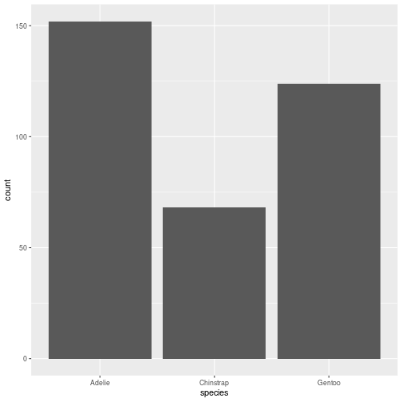

```r
penguins %>%
  ggplot(aes(x = species)) + geom_bar()
```

## 3.4 Ajout d’une variable

- pour enrichir la représentation, il peut être intéressant de croiser les variables

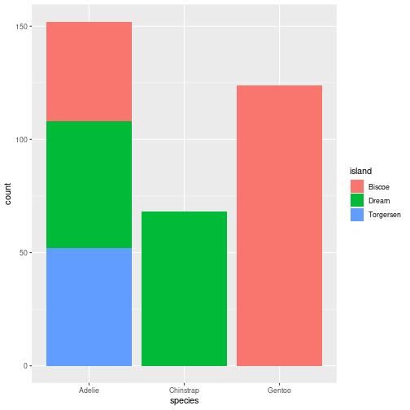

```r
penguins %>%
  ggplot(aes(x = species, fill = island)) + geom_bar()
```

- plusieurs variantes possibles

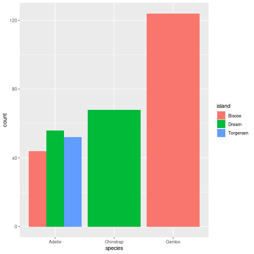

```r
penguins %>%
  ggplot(aes(x = species, fill = island)) +
  geom_bar(position = position_dodge())
```

## 3.5 Cosmétiques

- afin de rendre le graphique plus lisible

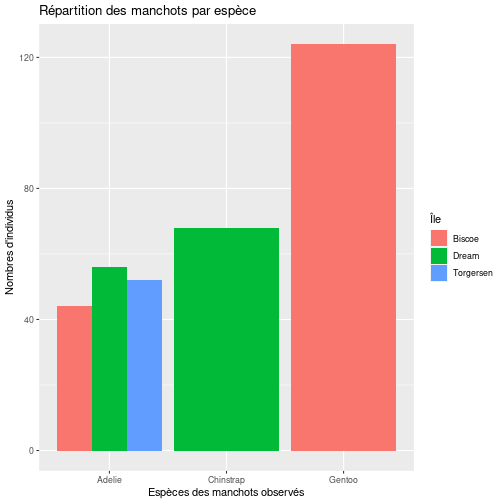

```r
penguins %>% ggplot(aes(x = species, fill = island)) +
  geom_bar(position = position_dodge()) +
  ggtitle("Répartition des manchots par espèce") +
  xlab("Espèces des manchots observés") +
  ylab("Nombres d'individus") +
  labs(fill = "Île") #labs() permet de régler beaucoup de choses
```

## 3.6 L’histogramme

- là encore il faut savoir si on veut un histogramme complet puis donner une répartition au sein d’une classe ou alors autant d’histogrammes que de modalités

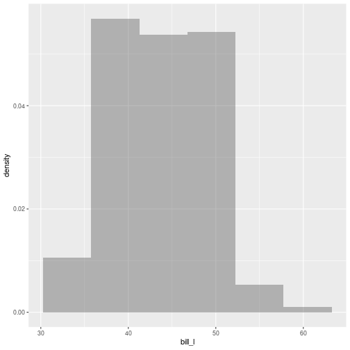

```r
penguins %>%
ggplot() +
geom_histogram(aes(x = bill_l, y = after_stat(density)), bins = 6, alpha = 0.4, position = "identity")
```

## 3.7 La boîte à moustache

- comme pour les diagrammes en bâtons

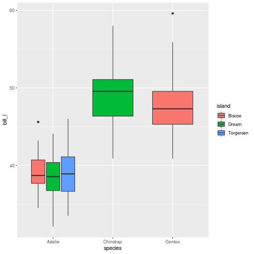

```r
penguins %>%
ggplot() +
aes(x = species, y = bill_l, fill = island) +
geom_boxplot()
```

## 3.8 Le nuage de points

- la fonction `geom_smooth()` permet d’ajouter les droites de régression par groupe ainsi que les intervalles de confiance sur la tendance

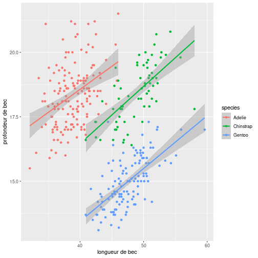

```r
penguins %>%
  ggplot() +
  aes(x = bill_l, y = bill_d, color = species) +
  labs(x = "longueur de bec", y = "profondeur de bec", fill = "Espèce") +
  geom_point() +
  geom_smooth(method = "lm")
```

## 3.9 Graphique d’interaction

- illustration d’un effet d’interaction dans un modèle linéaire

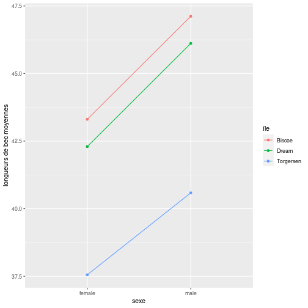

## 3.10 La magie des facettes

- possibilité de créer une mosaïque

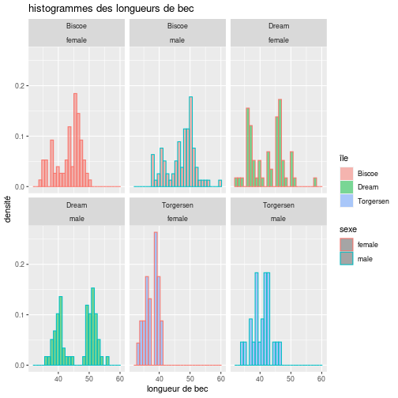

```r
penguins %>%
  na.omit() %>%
  ggplot() +
  aes(x = bill_l, y = after_stat(density), color = sex, fill = island) +
  geom_histogram(alpha = 0.5) +
  facet_wrap(~island+sex) +
  labs(x = "longueur de bec", y = "densité", title = "histogrammes des longueurs de bec", fill = "île", color = "sexe")
```

## 3.11 Disposer plusieurs sorties

- il existe plusieurs façons de diposer plusieurs graphiques suivant le rendu recherché, encore une fois on ne cherche pas ici à être exhaustif
- deux solutions présentées ici, la version directe avec le paquet `patchwork` et la seconde un peu plus complète mais plus lourde avec la fonction `ggpubr::ggarrange`

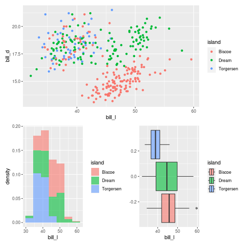

```r
p1 <- penguins %>% ggplot(aes(x=bill_l, y =bill_d, color = island)) + geom_point()
p2 <- penguins %>% ggplot(aes(x=bill_l, y = after_stat(density) , fill = island)) + geom_histogram(alpha = .6, bins = 7)
p3<- penguins %>% ggplot(aes(x=bill_l, fill = island)) + geom_boxplot(alpha = .6)
library(patchwork)
p1/(p2+p3)
```

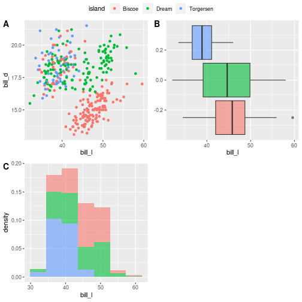

```r
library(ggpubr)
ggarrange(p1, p3, p2,
          labels = c("A", "B", "C"),
          ncol = 2, nrow = 2, common.legend = TRUE)
```

## 3.12 Ensuite ?

- énorme communauté autour de `tidyverse` et `ggplot`
- chaque question qu’on se pose à très certainement une réponse simple, concise (ou presque) et reproductible
- quelques sources
  - [Statistical tools for high-throughput data analysis](http://www.sthda.com/english/)
  - [Datanovia](https://www.datanovia.com/en/fr/)
  - [Stackoverflow](https://stackoverflow.com/)

# 4. Graphiques interactifs plotly

## 4.1 Des graphiques pour des rapports html

- le package `plotly` est porté sur plusieurs logiciels dont `R` et `Python`
- le fonctionnement - à la syntaxe près évidemment - est proche de celui de `ggplot2`
- à partir des sorties, il est possible d’enregistrer des images figées
- le passage de la souris sur le graphique permet de faire apparaître les informations utilisées pour le graphique, on peut zoomer sur certaines parties et sauver le zoom
- possibilité de réaliser des animations
- source assez complète : plotly.com

## 4.2 Les graphiques de base

- les fonctions changent et l’empilement se fait avec le pipe `%>%`

```r
penguins %>%
  plot_ly(x = ~bill_d, y = ~bill_l, type = "scatter", mode = "markers") %>%
  layout(
    title = "longueur de bec en fonction de la profondeur"
    xaxis = list(title = "profondeur de bec"),
    yaxis = list(title = "longueur de bec"))
```

[interactive chart not shown]

## 4.3 Les avantages de l’interactivité

- ce type de représentation peut vraiment être utile en phase exploratoire, prenons l’exemple des données de covid

[interactive chart not shown]

- code correspondant

```r
covid <- read.table(
  "owid-covid-data.csv",
  header = T,
  sep = ",",
  stringsAsFactors = TRUE
) %>%
  mutate(date = ymd(date)) %>%
  filter(
    location %in% c(
      "France",
      "United States",
      "Mexico",
      "Portugal",
      "Spain",
      "United Kingdom",
      "Brazil",
      "South Africa"
    ),
    (ymd(20201101) <= date) & (ymd(20210201) >= date)
  ) %>%
  droplevels()
covid %>% plot_ly(type = "scatter", mode = "lines") %>%
  add_trace(
    x = ~ date,
    y =  ~ new_cases,
    color = ~ location,
    fill = "tozeroy"
  ) %>%
  layout(
    title = 'COVID-19',
    xaxis = list(title = 'Date'),
    yaxis = list(title = 'Number of new cases'),
    legend = list(title = list(text = '<b> Countries </b>')),
    annotations = list(
      x = 1,
      y = -.1,
      text = "Source: https://ourworldindata.org/",
      showarrow = F,
      xref = 'paper',
      yref = 'paper',
      xanchor = 'right',
      yanchor = 'auto',
      xshift = 0,
      yshift = 0,
      font = list(size = 7)
    )
  )
```

## 4.4 De ggplot à plotly

- une fonction permet de transcrire un objet créé par `ggplot()` en un objet pouvant sortir de `plot_ly()`

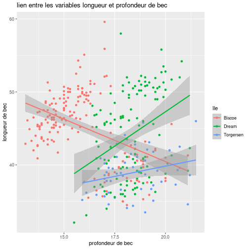

```r
p <- penguins %>% ggplot() +
  aes(x = bill_d, y = bill_l, color = island) +
  geom_point() +
  geom_smooth(method = "lm") +
  labs(title = "lien entre les variables longueur et profondeur de bec",
       x = "profondeur de bec",
       y = "longueur de bec",
       color = "île")
p
```

```r
p  %>%  ggplotly()
```

[interactive chart not shown]

---

## 4.5 Une petite animation pour finir

- outil pratique pour marquer une évolution temporelle, ou alors pour de la sensibilité aux paramètres

```r
penguins %>%
  plot_ly(x = ~bill_d, y = ~bill_l, frame = ~year, type = "scatter", mode = "markers") %>%
  layout(
    title = "longueur de bec en fonction de la profondeur",
    xaxis = list(title = "profondeur de bec"),
    yaxis = list(title = "longueur de bec"))
```

[interactive chart not shown]

# 5. Covariables spatiales

## 5.1 Le problème des cartes

- les objets qui permettent de définir des contours sont assez complexes
- de nombreux paquets (comme par ailleurs pour les séries temporelles car l’enregistrement du temps n’est pas simple non plus)
- le paquet `ggplot2` contient déjà de nombreux éléments
- par exemple :

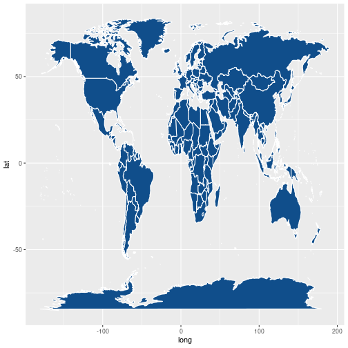

```r
world_map <- map_data("world")
ggplot(world_map, aes(x = long, y = lat, group = group)) +
  geom_polygon(fill="dodgerblue4", colour = "white")
```

## 5.2 Utilisation des cartes

- considérons les données suivantes

```r
arrests <- USArrests
head(arrests)
```

```
           Murder Assault UrbanPop Rape
Alabama      13.2     236       58 21.2
Alaska       10.0     263       48 44.5
Arizona       8.1     294       80 31.0
Arkansas      8.8     190       50 19.5
California    9.0     276       91 40.6
Colorado      7.9     204       78 38.7
```

- pour représenter géographiquement ces informations

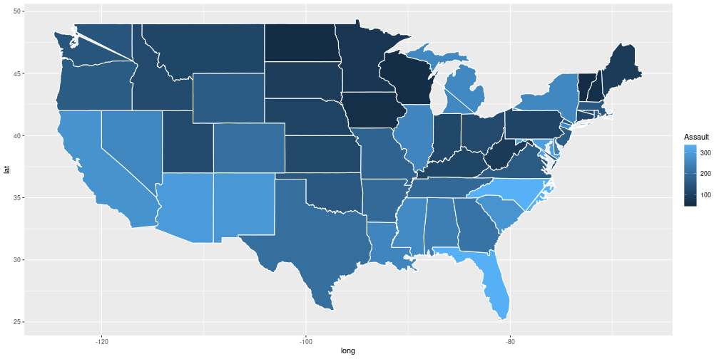

```r
states_map <- map_data("state")
arrests <- arrests %>%
  mutate(region = tolower(rownames(USArrests)))
arrests_map <- left_join(states_map, arrests, by = "region")
p <- arrests_map %>% ggplot() +
  aes(x = long, y= lat, group = region) +
  geom_polygon(aes(fill = Assault), color = "white")
p
```

## 5.3 Le problème de la projection

- il est possible de changer de méthode de projection

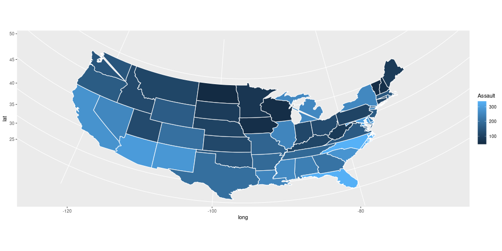

```r
p + coord_map(projection = "orthographic")
```

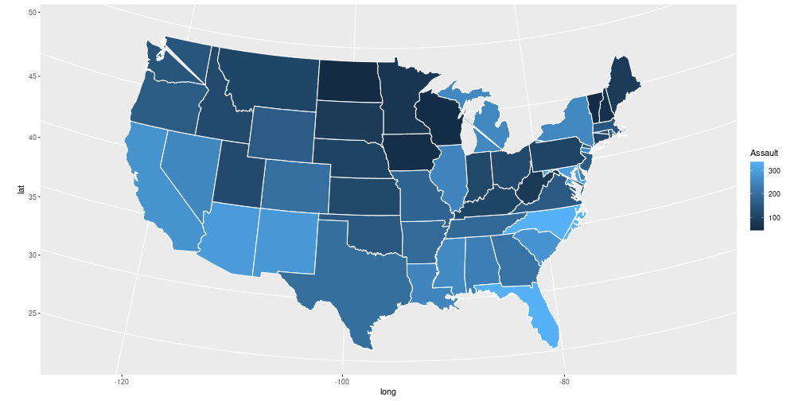

```r
p + coord_map(projection = "conic", lat0 = 30)
```

## 5.4 Rajouter les noms

- le nom de la région apparaît sur chaque ligne, il faut donc ne le faire apparaître qu’une fois

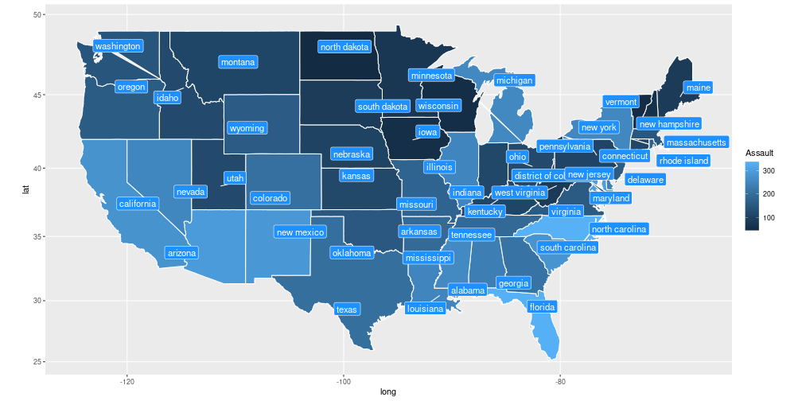

```r
region.lab.data <- arrests_map %>%
  group_by(region) %>%
  summarise(long = mean(long), lat = mean(lat))
library(ggrepel)
p +
  geom_label_repel(data = region.lab.data, aes(x = long, y = lat, label = region), size = 4 , colour = "white", fill = "dodgerblue") +
  coord_map()
```